# Risk Factor Analysis

## Outcome Variable

**Outcome Variable:** whz

## Predictor Variables

**Intervention Variable:** nhh

**Adjustment Set:**

- arm
- W_mage
- meducyrs
- feducyrs
- hhwealth_quart
- W_mhtcm
- W_mwtkg
- W_mbmi
- W_nrooms
- cleanck
- impfloor
- impsan
- safeh20
- delta_W_mage
- delta_meducyrs
- delta_feducyrs
- delta_hhwealth_quart
- delta_W_mhtcm
- delta_W_mwtkg
- delta_W_mbmi
- delta_W_nrooms
- delta_cleanck
- delta_impfloor
- delta_impsan
- delta_safeh20

## Stratifying Variables

The analysis was stratified on these variable(s):

- agecat
- studyid
- country

## Data Summary

| agecat | studyid | country | nhh | n_cell | n | outcome_variable |
| --- | --- | --- | --- | --- | --- | --- |
| Birth | IRC | INDIA | 3 or less | 52 | 343 | whz |
| Birth | IRC | INDIA | 4-5 | 131 | 343 | whz |
| Birth | IRC | INDIA | 6-7 | 84 | 343 | whz |
| Birth | IRC | INDIA | 8+ | 76 | 343 | whz |
| Birth | NIH-Birth | BANGLADESH | 3 or less | 104 | 575 | whz |
| Birth | NIH-Birth | BANGLADESH | 4-5 | 244 | 575 | whz |
| Birth | NIH-Birth | BANGLADESH | 6-7 | 130 | 575 | whz |
| Birth | NIH-Birth | BANGLADESH | 8+ | 97 | 575 | whz |
| Birth | NIH-Crypto | BANGLADESH | 3 or less | 103 | 707 | whz |
| Birth | NIH-Crypto | BANGLADESH | 4-5 | 318 | 707 | whz |
| Birth | NIH-Crypto | BANGLADESH | 6-7 | 167 | 707 | whz |
| Birth | NIH-Crypto | BANGLADESH | 8+ | 119 | 707 | whz |
| Birth | PROVIDE | BANGLADESH | 3 or less | 103 | 532 | whz |
| Birth | PROVIDE | BANGLADESH | 4-5 | 249 | 532 | whz |
| Birth | PROVIDE | BANGLADESH | 6-7 | 114 | 532 | whz |
| Birth | PROVIDE | BANGLADESH | 8+ | 66 | 532 | whz |
| 6 months | IRC | INDIA | 3 or less | 57 | 408 | whz |
| 6 months | IRC | INDIA | 4-5 | 157 | 408 | whz |
| 6 months | IRC | INDIA | 6-7 | 107 | 408 | whz |
| 6 months | IRC | INDIA | 8+ | 87 | 408 | whz |
| 6 months | LCNI-5 | MALAWI | 3 or less | 224 | 816 | whz |
| 6 months | LCNI-5 | MALAWI | 4-5 | 340 | 816 | whz |
| 6 months | LCNI-5 | MALAWI | 6-7 | 182 | 816 | whz |
| 6 months | LCNI-5 | MALAWI | 8+ | 70 | 816 | whz |
| 6 months | NIH-Birth | BANGLADESH | 3 or less | 95 | 537 | whz |
| 6 months | NIH-Birth | BANGLADESH | 4-5 | 227 | 537 | whz |
| 6 months | NIH-Birth | BANGLADESH | 6-7 | 128 | 537 | whz |
| 6 months | NIH-Birth | BANGLADESH | 8+ | 87 | 537 | whz |
| 6 months | NIH-Crypto | BANGLADESH | 3 or less | 104 | 715 | whz |
| 6 months | NIH-Crypto | BANGLADESH | 4-5 | 326 | 715 | whz |
| 6 months | NIH-Crypto | BANGLADESH | 6-7 | 170 | 715 | whz |
| 6 months | NIH-Crypto | BANGLADESH | 8+ | 115 | 715 | whz |
| 6 months | PROVIDE | BANGLADESH | 3 or less | 105 | 603 | whz |
| 6 months | PROVIDE | BANGLADESH | 4-5 | 289 | 603 | whz |
| 6 months | PROVIDE | BANGLADESH | 6-7 | 130 | 603 | whz |
| 6 months | PROVIDE | BANGLADESH | 8+ | 79 | 603 | whz |
| 6 months | SAS-FoodSuppl | INDIA | 3 or less | 33 | 380 | whz |
| 6 months | SAS-FoodSuppl | INDIA | 4-5 | 166 | 380 | whz |
| 6 months | SAS-FoodSuppl | INDIA | 6-7 | 115 | 380 | whz |
| 6 months | SAS-FoodSuppl | INDIA | 8+ | 66 | 380 | whz |
| 24 months | IRC | INDIA | 3 or less | 58 | 409 | whz |
| 24 months | IRC | INDIA | 4-5 | 158 | 409 | whz |
| 24 months | IRC | INDIA | 6-7 | 107 | 409 | whz |
| 24 months | IRC | INDIA | 8+ | 86 | 409 | whz |
| 24 months | LCNI-5 | MALAWI | 3 or less | 157 | 558 | whz |
| 24 months | LCNI-5 | MALAWI | 4-5 | 230 | 558 | whz |
| 24 months | LCNI-5 | MALAWI | 6-7 | 123 | 558 | whz |
| 24 months | LCNI-5 | MALAWI | 8+ | 48 | 558 | whz |
| 24 months | NIH-Birth | BANGLADESH | 3 or less | 74 | 428 | whz |
| 24 months | NIH-Birth | BANGLADESH | 4-5 | 184 | 428 | whz |
| 24 months | NIH-Birth | BANGLADESH | 6-7 | 100 | 428 | whz |
| 24 months | NIH-Birth | BANGLADESH | 8+ | 70 | 428 | whz |
| 24 months | NIH-Crypto | BANGLADESH | 3 or less | 69 | 514 | whz |
| 24 months | NIH-Crypto | BANGLADESH | 4-5 | 232 | 514 | whz |
| 24 months | NIH-Crypto | BANGLADESH | 6-7 | 130 | 514 | whz |
| 24 months | NIH-Crypto | BANGLADESH | 8+ | 83 | 514 | whz |
| 24 months | PROVIDE | BANGLADESH | 3 or less | 106 | 579 | whz |
| 24 months | PROVIDE | BANGLADESH | 4-5 | 273 | 579 | whz |
| 24 months | PROVIDE | BANGLADESH | 6-7 | 117 | 579 | whz |
| 24 months | PROVIDE | BANGLADESH | 8+ | 83 | 579 | whz |

The following strata were considered:

- agecat: 24 months, studyid: IRC, country: INDIA
- agecat: 24 months, studyid: LCNI-5, country: MALAWI
- agecat: 24 months, studyid: NIH-Birth, country: BANGLADESH
- agecat: 24 months, studyid: NIH-Crypto, country: BANGLADESH
- agecat: 24 months, studyid: PROVIDE, country: BANGLADESH
- agecat: 6 months, studyid: IRC, country: INDIA
- agecat: 6 months, studyid: LCNI-5, country: MALAWI
- agecat: 6 months, studyid: NIH-Birth, country: BANGLADESH
- agecat: 6 months, studyid: NIH-Crypto, country: BANGLADESH
- agecat: 6 months, studyid: PROVIDE, country: BANGLADESH
- agecat: 6 months, studyid: SAS-FoodSuppl, country: INDIA
- agecat: Birth, studyid: IRC, country: INDIA
- agecat: Birth, studyid: NIH-Birth, country: BANGLADESH
- agecat: Birth, studyid: NIH-Crypto, country: BANGLADESH
- agecat: Birth, studyid: PROVIDE, country: BANGLADESH

## Methods Detail

We’re interested in the causal parameters $E[Y_a]$ for all values of $a \in \mathcal{A}$. These parameters represent the mean outcome if, possibly contrary to fact, we intervened to set all units to have $A=a$. Under the randomization and positivity assumptions, these are identified by the statistical parameters $\psi_a=E_W[E_{Y|A,W}(Y|A=a,W)]$. In addition, we’re interested in the mean of $Y$, $E[Y]$ under no intervention (the observed mean). We will estimate these parameters by using SuperLearner to fit the relevant likelihood factors – $E_{Y|A,W}(Y|A=a,W)$ and $p(A=a|W)$, and then updating our likelihood fit using a joint TMLE.

For unadjusted analyses ($W=\{\}$), initial likelihoods were estimated using Lrnr_glm to estimate the simple $E(Y|A)$ and Lrnr_mean to estimate $p(A)$. For adjusted analyses, a small library containing Lrnr_glmnet, Lrnr_xgboost, and Lrnr_mean was used.

Having estimated these parameters, we will then use the delta method to estimate relative risks and attributable risks relative to a prespecified baseline level of $A$.

# Results Detail

## Results Plots

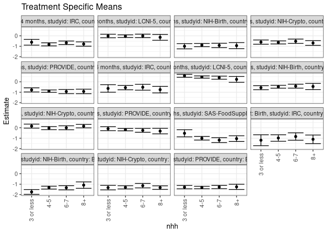

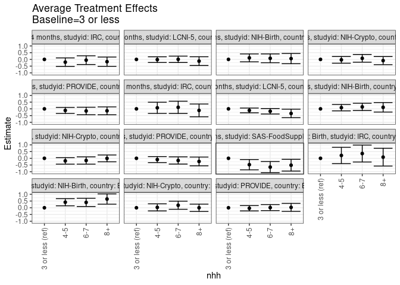

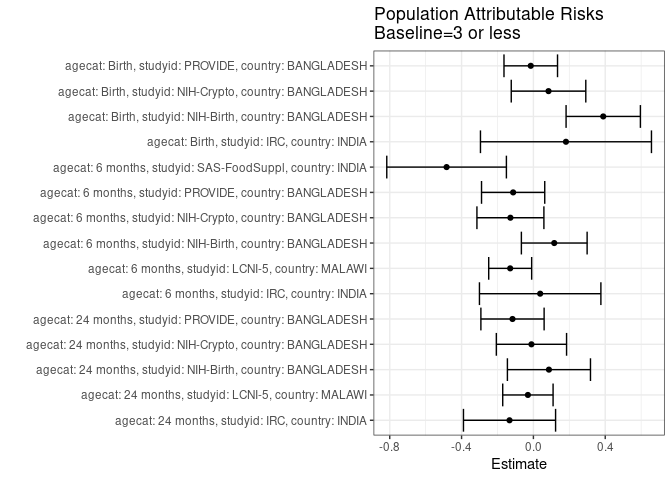

## Results Table

### Parameter: TSM

| agecat | studyid | country | intervention_level | baseline_level | estimate | ci_lower | ci_upper |
| --- | --- | --- | --- | --- | --- | --- | --- |
| Birth | IRC | INDIA | 3 or less | NA | -1.1918794 | -1.7122003 | -0.6715586 |
| Birth | IRC | INDIA | 4-5 | NA | -0.9795179 | -1.2882586 | -0.6707772 |
| Birth | IRC | INDIA | 6-7 | NA | -0.8375729 | -1.1897833 | -0.4853626 |
| Birth | IRC | INDIA | 8+ | NA | -1.1046667 | -1.5150170 | -0.6943165 |
| Birth | NIH-Birth | BANGLADESH | 3 or less | NA | -1.7387977 | -1.9671252 | -1.5104702 |
| Birth | NIH-Birth | BANGLADESH | 4-5 | NA | -1.3269223 | -1.4648917 | -1.1889529 |
| Birth | NIH-Birth | BANGLADESH | 6-7 | NA | -1.3406388 | -1.5425876 | -1.1386899 |
| Birth | NIH-Birth | BANGLADESH | 8+ | NA | -1.0888284 | -1.3943237 | -0.7833330 |
| Birth | NIH-Crypto | BANGLADESH | 3 or less | NA | -1.3283551 | -1.5432040 | -1.1135061 |
| Birth | NIH-Crypto | BANGLADESH | 4-5 | NA | -1.3004081 | -1.4540406 | -1.1467756 |
| Birth | NIH-Crypto | BANGLADESH | 6-7 | NA | -1.1414238 | -1.3536779 | -0.9291698 |
| Birth | NIH-Crypto | BANGLADESH | 8+ | NA | -1.3283343 | -1.4955200 | -1.1611487 |
| Birth | PROVIDE | BANGLADESH | 3 or less | NA | -1.2837118 | -1.4451393 | -1.1222842 |
| Birth | PROVIDE | BANGLADESH | 4-5 | NA | -1.3204935 | -1.4377084 | -1.2032786 |
| Birth | PROVIDE | BANGLADESH | 6-7 | NA | -1.2728437 | -1.4289547 | -1.1167326 |
| Birth | PROVIDE | BANGLADESH | 8+ | NA | -1.2537670 | -1.5041965 | -1.0033376 |
| 6 months | IRC | INDIA | 3 or less | NA | -0.6365941 | -0.9962366 | -0.2769515 |
| 6 months | IRC | INDIA | 4-5 | NA | -0.5596592 | -0.7684167 | -0.3509018 |
| 6 months | IRC | INDIA | 6-7 | NA | -0.5223799 | -0.8013629 | -0.2433969 |
| 6 months | IRC | INDIA | 8+ | NA | -0.7517209 | -1.0616852 | -0.4417565 |
| 6 months | LCNI-5 | MALAWI | 3 or less | NA | 0.5710697 | 0.4301210 | 0.7120184 |
| 6 months | LCNI-5 | MALAWI | 4-5 | NA | 0.4545749 | 0.3455699 | 0.5635798 |
| 6 months | LCNI-5 | MALAWI | 6-7 | NA | 0.3921625 | 0.2455272 | 0.5387978 |
| 6 months | LCNI-5 | MALAWI | 8+ | NA | 0.2311667 | -0.0498322 | 0.5121656 |
| 6 months | NIH-Birth | BANGLADESH | 3 or less | NA | -0.5634965 | -0.7587051 | -0.3682880 |
| 6 months | NIH-Birth | BANGLADESH | 4-5 | NA | -0.4734041 | -0.6120381 | -0.3347701 |
| 6 months | NIH-Birth | BANGLADESH | 6-7 | NA | -0.4171058 | -0.6058306 | -0.2283810 |
| 6 months | NIH-Birth | BANGLADESH | 8+ | NA | -0.4488872 | -0.7426632 | -0.1551111 |
| 6 months | NIH-Crypto | BANGLADESH | 3 or less | NA | 0.1577926 | -0.0326470 | 0.3482322 |
| 6 months | NIH-Crypto | BANGLADESH | 4-5 | NA | -0.0333120 | -0.1825747 | 0.1159507 |
| 6 months | NIH-Crypto | BANGLADESH | 6-7 | NA | -0.0044477 | -0.1957002 | 0.1868047 |
| 6 months | NIH-Crypto | BANGLADESH | 8+ | NA | 0.1524798 | -0.0145423 | 0.3195019 |
| 6 months | PROVIDE | BANGLADESH | 3 or less | NA | -0.0861997 | -0.2793566 | 0.1069572 |
| 6 months | PROVIDE | BANGLADESH | 4-5 | NA | -0.1807058 | -0.2957369 | -0.0656747 |
| 6 months | PROVIDE | BANGLADESH | 6-7 | NA | -0.2468256 | -0.4320620 | -0.0615892 |
| 6 months | PROVIDE | BANGLADESH | 8+ | NA | -0.3192256 | -0.5837536 | -0.0546976 |
| 6 months | SAS-FoodSuppl | INDIA | 3 or less | NA | -0.5287128 | -0.8683474 | -0.1890781 |
| 6 months | SAS-FoodSuppl | INDIA | 4-5 | NA | -1.0018946 | -1.1775061 | -0.8262830 |
| 6 months | SAS-FoodSuppl | INDIA | 6-7 | NA | -1.1818262 | -1.4162934 | -0.9473589 |
| 6 months | SAS-FoodSuppl | INDIA | 8+ | NA | -1.0398285 | -1.3139594 | -0.7656977 |
| 24 months | IRC | INDIA | 3 or less | NA | -0.6128442 | -0.8897541 | -0.3359344 |
| 24 months | IRC | INDIA | 4-5 | NA | -0.8166332 | -0.9655910 | -0.6676755 |
| 24 months | IRC | INDIA | 6-7 | NA | -0.6683603 | -0.8374404 | -0.4992803 |
| 24 months | IRC | INDIA | 8+ | NA | -0.7829958 | -0.9868543 | -0.5791373 |
| 24 months | LCNI-5 | MALAWI | 3 or less | NA | -0.0171458 | -0.1857673 | 0.1514757 |
| 24 months | LCNI-5 | MALAWI | 4-5 | NA | -0.0339739 | -0.1623684 | 0.0944205 |
| 24 months | LCNI-5 | MALAWI | 6-7 | NA | -0.0094133 | -0.1769217 | 0.1580951 |
| 24 months | LCNI-5 | MALAWI | 8+ | NA | -0.1450331 | -0.4240330 | 0.1339668 |
| 24 months | NIH-Birth | BANGLADESH | 3 or less | NA | -0.9980961 | -1.2496569 | -0.7465352 |
| 24 months | NIH-Birth | BANGLADESH | 4-5 | NA | -0.8841273 | -1.0340247 | -0.7342299 |
| 24 months | NIH-Birth | BANGLADESH | 6-7 | NA | -0.9166147 | -1.1260617 | -0.7071678 |
| 24 months | NIH-Birth | BANGLADESH | 8+ | NA | -0.9375793 | -1.2240503 | -0.6511083 |
| 24 months | NIH-Crypto | BANGLADESH | 3 or less | NA | -0.5994877 | -0.8006917 | -0.3982837 |
| 24 months | NIH-Crypto | BANGLADESH | 4-5 | NA | -0.6317056 | -0.7791238 | -0.4842873 |
| 24 months | NIH-Crypto | BANGLADESH | 6-7 | NA | -0.5185720 | -0.7238047 | -0.3133393 |
| 24 months | NIH-Crypto | BANGLADESH | 8+ | NA | -0.6872268 | -0.9128220 | -0.4616316 |
| 24 months | PROVIDE | BANGLADESH | 3 or less | NA | -0.7764939 | -0.9709887 | -0.5819992 |
| 24 months | PROVIDE | BANGLADESH | 4-5 | NA | -0.8944771 | -1.0101008 | -0.7788534 |
| 24 months | PROVIDE | BANGLADESH | 6-7 | NA | -0.9338035 | -1.1339069 | -0.7337001 |
| 24 months | PROVIDE | BANGLADESH | 8+ | NA | -0.9234344 | -1.1412678 | -0.7056009 |

### Parameter: E(Y)

| agecat | studyid | country | intervention_level | baseline_level | estimate | ci_lower | ci_upper |
| --- | --- | --- | --- | --- | --- | --- | --- |
| Birth | IRC | INDIA | NA | NA | -1.0105831 | -1.1973019 | -0.8238643 |
| Birth | NIH-Birth | BANGLADESH | NA | NA | -1.3499217 | -1.4444634 | -1.2553801 |
| Birth | NIH-Crypto | BANGLADESH | NA | NA | -1.2441513 | -1.3281130 | -1.1601897 |
| Birth | PROVIDE | BANGLADESH | NA | NA | -1.2984586 | -1.3752758 | -1.2216415 |
| 6 months | IRC | INDIA | NA | NA | -0.5989297 | -0.7344491 | -0.4634104 |
| 6 months | LCNI-5 | MALAWI | NA | NA | 0.4417647 | 0.3702742 | 0.5132552 |
| 6 months | NIH-Birth | BANGLADESH | NA | NA | -0.4474038 | -0.5378167 | -0.3569909 |
| 6 months | NIH-Crypto | BANGLADESH | NA | NA | 0.0297622 | -0.0491685 | 0.1086930 |
| 6 months | PROVIDE | BANGLADESH | NA | NA | -0.1990907 | -0.2817968 | -0.1163845 |
| 6 months | SAS-FoodSuppl | INDIA | NA | NA | -1.0121579 | -1.1280429 | -0.8962729 |
| 24 months | IRC | INDIA | NA | NA | -0.7458150 | -0.8368180 | -0.6548120 |
| 24 months | LCNI-5 | MALAWI | NA | NA | -0.0477867 | -0.1301103 | 0.0345368 |
| 24 months | NIH-Birth | BANGLADESH | NA | NA | -0.9115790 | -1.0095022 | -0.8136559 |
| 24 months | NIH-Crypto | BANGLADESH | NA | NA | -0.6103502 | -0.7050157 | -0.5156847 |
| 24 months | PROVIDE | BANGLADESH | NA | NA | -0.8928670 | -0.9755153 | -0.8102187 |

### Parameter: ATE

| agecat | studyid | country | intervention_level | baseline_level | estimate | ci_lower | ci_upper |
| --- | --- | --- | --- | --- | --- | --- | --- |
| Birth | IRC | INDIA | 3 or less | 3 or less | 0.0000000 | 0.0000000 | 0.0000000 |
| Birth | IRC | INDIA | 4-5 | 3 or less | 0.2123615 | -0.3930384 | 0.8177614 |
| Birth | IRC | INDIA | 6-7 | 3 or less | 0.3543065 | -0.2732050 | 0.9818180 |
| Birth | IRC | INDIA | 8+ | 3 or less | 0.0872127 | -0.5741389 | 0.7485643 |
| Birth | NIH-Birth | BANGLADESH | 3 or less | 3 or less | 0.0000000 | 0.0000000 | 0.0000000 |
| Birth | NIH-Birth | BANGLADESH | 4-5 | 3 or less | 0.4118754 | 0.1452493 | 0.6785016 |
| Birth | NIH-Birth | BANGLADESH | 6-7 | 3 or less | 0.3981590 | 0.0930662 | 0.7032517 |
| Birth | NIH-Birth | BANGLADESH | 8+ | 3 or less | 0.6499694 | 0.2688670 | 1.0310718 |
| Birth | NIH-Crypto | BANGLADESH | 3 or less | 3 or less | 0.0000000 | 0.0000000 | 0.0000000 |
| Birth | NIH-Crypto | BANGLADESH | 4-5 | 3 or less | 0.0279469 | -0.2359509 | 0.2918448 |
| Birth | NIH-Crypto | BANGLADESH | 6-7 | 3 or less | 0.1869312 | -0.1149858 | 0.4888482 |
| Birth | NIH-Crypto | BANGLADESH | 8+ | 3 or less | 0.0000207 | -0.2719528 | 0.2719942 |
| Birth | PROVIDE | BANGLADESH | 3 or less | 3 or less | 0.0000000 | 0.0000000 | 0.0000000 |
| Birth | PROVIDE | BANGLADESH | 4-5 | 3 or less | -0.0367818 | -0.2363280 | 0.1627645 |
| Birth | PROVIDE | BANGLADESH | 6-7 | 3 or less | 0.0108681 | -0.2134871 | 0.2352233 |
| Birth | PROVIDE | BANGLADESH | 8+ | 3 or less | 0.0299447 | -0.2680490 | 0.3279384 |
| 6 months | IRC | INDIA | 3 or less | 3 or less | 0.0000000 | 0.0000000 | 0.0000000 |
| 6 months | IRC | INDIA | 4-5 | 3 or less | 0.0769348 | -0.3388713 | 0.4927409 |
| 6 months | IRC | INDIA | 6-7 | 3 or less | 0.1142142 | -0.3409120 | 0.5693403 |
| 6 months | IRC | INDIA | 8+ | 3 or less | -0.1151268 | -0.5903580 | 0.3601044 |
| 6 months | LCNI-5 | MALAWI | 3 or less | 3 or less | 0.0000000 | 0.0000000 | 0.0000000 |
| 6 months | LCNI-5 | MALAWI | 4-5 | 3 or less | -0.1164949 | -0.2940569 | 0.0610672 |
| 6 months | LCNI-5 | MALAWI | 6-7 | 3 or less | -0.1789072 | -0.3818224 | 0.0240080 |
| 6 months | LCNI-5 | MALAWI | 8+ | 3 or less | -0.3399030 | -0.6541102 | -0.0256958 |
| 6 months | NIH-Birth | BANGLADESH | 3 or less | 3 or less | 0.0000000 | 0.0000000 | 0.0000000 |
| 6 months | NIH-Birth | BANGLADESH | 4-5 | 3 or less | 0.0900924 | -0.1490320 | 0.3292169 |
| 6 months | NIH-Birth | BANGLADESH | 6-7 | 3 or less | 0.1463907 | -0.1234810 | 0.4162624 |
| 6 months | NIH-Birth | BANGLADESH | 8+ | 3 or less | 0.1146094 | -0.2372600 | 0.4664788 |
| 6 months | NIH-Crypto | BANGLADESH | 3 or less | 3 or less | 0.0000000 | 0.0000000 | 0.0000000 |
| 6 months | NIH-Crypto | BANGLADESH | 4-5 | 3 or less | -0.1911046 | -0.4328983 | 0.0506890 |
| 6 months | NIH-Crypto | BANGLADESH | 6-7 | 3 or less | -0.1622403 | -0.4318342 | 0.1073535 |
| 6 months | NIH-Crypto | BANGLADESH | 8+ | 3 or less | -0.0053128 | -0.2583865 | 0.2477609 |
| 6 months | PROVIDE | BANGLADESH | 3 or less | 3 or less | 0.0000000 | 0.0000000 | 0.0000000 |
| 6 months | PROVIDE | BANGLADESH | 4-5 | 3 or less | -0.0945061 | -0.3188198 | 0.1298075 |
| 6 months | PROVIDE | BANGLADESH | 6-7 | 3 or less | -0.1606259 | -0.4279948 | 0.1067430 |
| 6 months | PROVIDE | BANGLADESH | 8+ | 3 or less | -0.2330259 | -0.5602835 | 0.0942316 |
| 6 months | SAS-FoodSuppl | INDIA | 3 or less | 3 or less | 0.0000000 | 0.0000000 | 0.0000000 |
| 6 months | SAS-FoodSuppl | INDIA | 4-5 | 3 or less | -0.4731818 | -0.8554293 | -0.0909343 |
| 6 months | SAS-FoodSuppl | INDIA | 6-7 | 3 or less | -0.6531134 | -1.0667060 | -0.2395208 |
| 6 months | SAS-FoodSuppl | INDIA | 8+ | 3 or less | -0.5111157 | -0.9473648 | -0.0748667 |
| 24 months | IRC | INDIA | 3 or less | 3 or less | 0.0000000 | 0.0000000 | 0.0000000 |
| 24 months | IRC | INDIA | 4-5 | 3 or less | -0.2037890 | -0.5183061 | 0.1107281 |
| 24 months | IRC | INDIA | 6-7 | 3 or less | -0.0555161 | -0.3799767 | 0.2689445 |
| 24 months | IRC | INDIA | 8+ | 3 or less | -0.1701516 | -0.5141567 | 0.1738536 |
| 24 months | LCNI-5 | MALAWI | 3 or less | 3 or less | 0.0000000 | 0.0000000 | 0.0000000 |
| 24 months | LCNI-5 | MALAWI | 4-5 | 3 or less | -0.0168281 | -0.2285983 | 0.1949422 |
| 24 months | LCNI-5 | MALAWI | 6-7 | 3 or less | 0.0077325 | -0.2300282 | 0.2454933 |
| 24 months | LCNI-5 | MALAWI | 8+ | 3 or less | -0.1278872 | -0.4537594 | 0.1979849 |
| 24 months | NIH-Birth | BANGLADESH | 3 or less | 3 or less | 0.0000000 | 0.0000000 | 0.0000000 |
| 24 months | NIH-Birth | BANGLADESH | 4-5 | 3 or less | 0.1139688 | -0.1784652 | 0.4064027 |
| 24 months | NIH-Birth | BANGLADESH | 6-7 | 3 or less | 0.0814813 | -0.2454515 | 0.4084142 |
| 24 months | NIH-Birth | BANGLADESH | 8+ | 3 or less | 0.0605167 | -0.3202019 | 0.4412354 |
| 24 months | NIH-Crypto | BANGLADESH | 3 or less | 3 or less | 0.0000000 | 0.0000000 | 0.0000000 |
| 24 months | NIH-Crypto | BANGLADESH | 4-5 | 3 or less | -0.0322179 | -0.2813095 | 0.2168738 |
| 24 months | NIH-Crypto | BANGLADESH | 6-7 | 3 or less | 0.0809157 | -0.2056638 | 0.3674953 |
| 24 months | NIH-Crypto | BANGLADESH | 8+ | 3 or less | -0.0877391 | -0.3895628 | 0.2140847 |
| 24 months | PROVIDE | BANGLADESH | 3 or less | 3 or less | 0.0000000 | 0.0000000 | 0.0000000 |
| 24 months | PROVIDE | BANGLADESH | 4-5 | 3 or less | -0.1179832 | -0.3427622 | 0.1067959 |
| 24 months | PROVIDE | BANGLADESH | 6-7 | 3 or less | -0.1573096 | -0.4362205 | 0.1216014 |
| 24 months | PROVIDE | BANGLADESH | 8+ | 3 or less | -0.1469404 | -0.4389354 | 0.1450546 |

### Parameter: PAR

| agecat | studyid | country | intervention_level | baseline_level | estimate | ci_lower | ci_upper |
| --- | --- | --- | --- | --- | --- | --- | --- |
| Birth | IRC | INDIA | 3 or less | NA | 0.1812963 | -0.2948129 | 0.6574056 |
| Birth | NIH-Birth | BANGLADESH | 3 or less | NA | 0.3888760 | 0.1819466 | 0.5958054 |
| Birth | NIH-Crypto | BANGLADESH | 3 or less | NA | 0.0842037 | -0.1233328 | 0.2917403 |
| Birth | PROVIDE | BANGLADESH | 3 or less | NA | -0.0147469 | -0.1638213 | 0.1343275 |
| 6 months | IRC | INDIA | 3 or less | NA | 0.0376643 | -0.3004501 | 0.3757787 |
| 6 months | LCNI-5 | MALAWI | 3 or less | NA | -0.1293050 | -0.2489030 | -0.0097070 |
| 6 months | NIH-Birth | BANGLADESH | 3 or less | NA | 0.1160927 | -0.0669516 | 0.2991371 |
| 6 months | NIH-Crypto | BANGLADESH | 3 or less | NA | -0.1280304 | -0.3144971 | 0.0584364 |
| 6 months | PROVIDE | BANGLADESH | 3 or less | NA | -0.1128910 | -0.2888709 | 0.0630889 |
| 6 months | SAS-FoodSuppl | INDIA | 3 or less | NA | -0.4834451 | -0.8165421 | -0.1503481 |
| 24 months | IRC | INDIA | 3 or less | NA | -0.1329707 | -0.3894572 | 0.1235157 |
| 24 months | LCNI-5 | MALAWI | 3 or less | NA | -0.0306409 | -0.1708733 | 0.1095915 |
| 24 months | NIH-Birth | BANGLADESH | 3 or less | NA | 0.0865170 | -0.1447928 | 0.3178269 |
| 24 months | NIH-Crypto | BANGLADESH | 3 or less | NA | -0.0108625 | -0.2063881 | 0.1846631 |
| 24 months | PROVIDE | BANGLADESH | 3 or less | NA | -0.1163731 | -0.2924198 | 0.0596736 |